# Banco de Dados para Estatística e Ciência de Dados

## Ponte: SQL e R

A ponte entre o SQL e o R é mais simples do que parece:

1. O **SQL busca os dados** no banco.

2. O **R analisa e visualiza** esses dados.

## Pacotes que a gente vai usar

O R tem pacotes que permitem você se conectar direto a um banco de dados e rodar queries SQL sem sair do RStudio.

Instalação (só precisa fazer uma vez):

```r
install.packages("DBI")
install.packages("RSQLite")
```

Carregamento (em todo script):

```r
library(DBI)
library(RSQLite)
```

- `DBI:` Permite que o R se comunique com com bancos de dados.
- `RSQLite:` É o “driver” que permite o R se comunicar com bancos SQLite. Se fosse MySQL, PostgreSQL, ou outro SGBD, você instalaria o driver correspondente.

## O SQLite: banco sem servidor

Pra não depender de nenhum servidor externo, a gente vai usar o **SQLite**, que cria o banco num arquivo local.

É perfeito pra aprender porque:

- Não precisa instalar nada além do pacote
- O banco fica num arquivo no seu computador
- Funciona igual a qualquer outro banco, por dentro

### Conectando o R com o banco de dados SQLite

Cria (ou conecta) um banco de dados relacional SQLite, chamado: `hospital.db`

```r
# Conectando com o banco SQLite
con <- dbConnect(RSQLite::SQLite(), "hospital.db")
```

Pronto. Agora `con` é a sua conexão. Você vai passar ela em tudo que fizer daqui pra frente.

Sempre que terminar de usar o banco, fecha a conexão: `dbDisconnect(con)`. Não fecha na hora, mas lembra de colocar no final do script.

## Criação e manipulação do banco de dados Hospital

```r
library(DBI)
library(RSQLite)

con <- dbConnect(RSQLite::SQLite(), "hospital.db")
dbExecute(
  con,
  "
  CREATE TABLE paciente (
  id_paciente INTEGER PRIMARY KEY,
  nome TEXT,
  idade INTEGER,
  cidade TEXT)
  "
)
```

```
[1] 0
```

```r
dbExecute(
  con,
  "
  CREATE TABLE consulta (
  id_consulta INTEGER PRIMARY KEY,
  id_paciente INTEGER,
  especialidade TEXT,
  data TEXT)
  "
)
```

```
[1] 0
```

```r
dbExecute(
  con,
  "
  INSERT INTO paciente (id_paciente, nome, idade, cidade)
  VALUES
    (1,'Maria',39,'Fortaleza'),
    (2,'João',52,'Recife'),
    (3,'Ana',27,'Natal'),
    (4,'Carlos',45,'João Pessoa'),
    (5,'Beatriz',63,'Sobral'),
    (6,'Lucas',31,'Campina Grande')
  "
)
```

```
[1] 6
```

```r
dbExecute(
  con,
  "
  INSERT INTO consulta (id_consulta, id_paciente, especialidade, data)
  VALUES
    (10,1,'Cardiologia','2025-08-12'),
    (11,2,'Ortopedia','2025-08-13'),
    (12,3,'Dermatologia','2025-08-13'),
    (13,5,'Cardiologia','2025-08-14'),
    (14,2,'Cardiologia','2025-08-15'),
    (15,6,'Ortopedia','2025-08-15'),
    (16,1,'Nutrição','2025-08-15'),
    (17,4,'Ortopedia','2025-08-18'),
    (18,3,'Cardiologia','2025-08-19'),
    (19,5,'Dermatologia','2025-08-19'),
    (20,6,'Nutrição','2025-08-20')
 "
)
```

```
[1] 11
```

### Analise descritiva das espcialidades

```r
consultas <- dbGetQuery(
  con,
  "
  SELECT especialidade, COUNT(*) AS total
  FROM consulta
  GROUP BY especialidade
  ORDER BY total DESC
"
)

barplot(
  consultas$total,
  names.arg = consultas$especialidade,
  main = "Consultas por especialidade",
  ylab = "Total",
  col = "#4DABB8",
  cex.names = 1.2,
  cex.axis = 1.2,
  cex.main = 1.4
)
```

## Consultas por especialidade

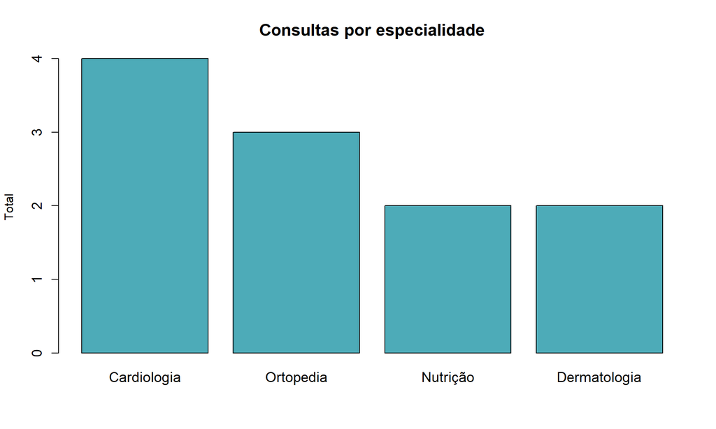

## Resumo: SQL + R

Banco de Dados

- SQLite, MySQL, PostgreSQL…
- Os dados ficam guardados aqui

→

DBI + driver

- `dbConnect()`
- `dbGetQuery()`
- `dbExecute()`

→

R

- R base pra explorar e visualizar

O SQL continua fazendo o que faz de melhor: buscar, filtrar e agregar dados. O R entra depois pra análise e visualização. Você não precisa escolher um ou outro.

## Perguntas rápidas

O que são dados, na sua própria palavra?

Por que não dá pra resolver tudo só com planilha?

Qual a diferença entre banco de dados e SGBD?

Por que o `WHERE` é tão importante no `UPDATE` e no `DELETE`?

O que acontece se tentarmos inserir uma consulta de um paciente que não existe?

## Obrigado

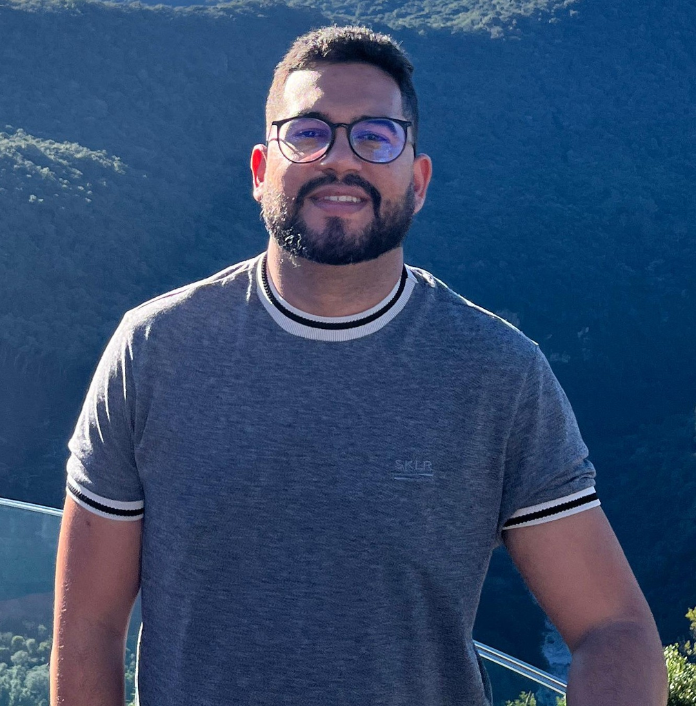

### Professor Pedro Almeida

**E-mail**

pedroalmeida@servidor.uepb.edu.br

**Site Acadêmico**

https://pedroallmeiida.github.io/website_uepb

**Redes Sociais e Acadêmicas**

- [GitHub](https://github.com/pedroallmeiida)
- [LinkedIn](https://www.linkedin.com/in/pedro-almeida-1b9676122/)

[figure not shown]

Bancos de Dados e SQL